# pulse_of_melbourne-presentation

[figure not shown]

**Pulse of Melbourne**

How does Melbourne move, and what changes its rhythm?

ETC5543 · EBS-Business Analytics Project

Richa Anghan · Zhuo Zhang · Nishta Bollavaram

[figure not shown]

Photo: Luis Enrique Ascui / NCA NewsWire, via news.com.au

## Flinders Street came alive after dark

[interactive chart not shown]

## Beyond Flinders Street

Melbourne’s pedestrian sensor network

[interactive chart not shown]

**What we’ll explore**

- **Time:** Daily, weekly and seasonal rhythms
- **Change:** Long-term trends and COVID-19
- **Space:** Activity across different locations
- **Disruptions:** Events, rainfall and public holidays

## How Melbourne’s sensor network evolved

### Our data

- **7.52 million** hourly observations
- **May 2009 – October 2026**
- **Source:** City of Melbourne pedestrian-counting system
- **Preparation:** Historical and recent records combined and validated

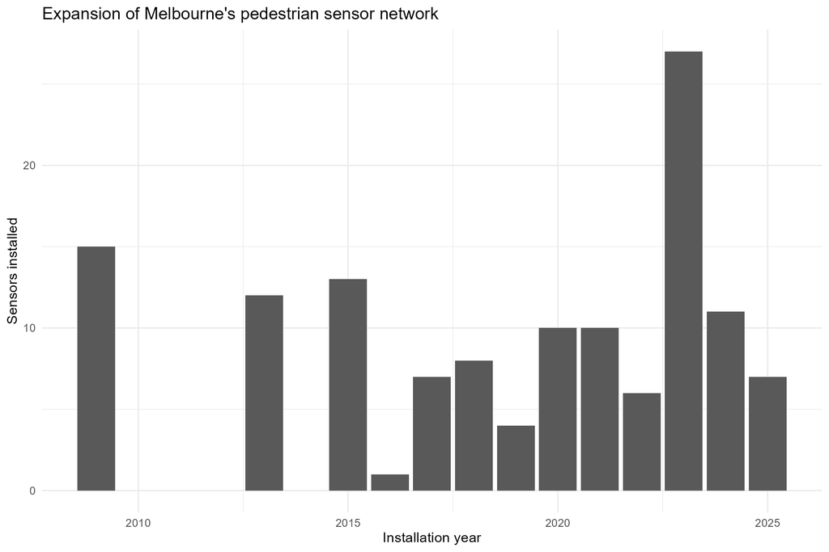

## Melbourne has its own daily rhythm

[interactive chart not shown]

## How has Melbourne’s weekly rhythm changed?

[interactive chart not shown]

## Melbourne’s pedestrian activity changes with the seasons

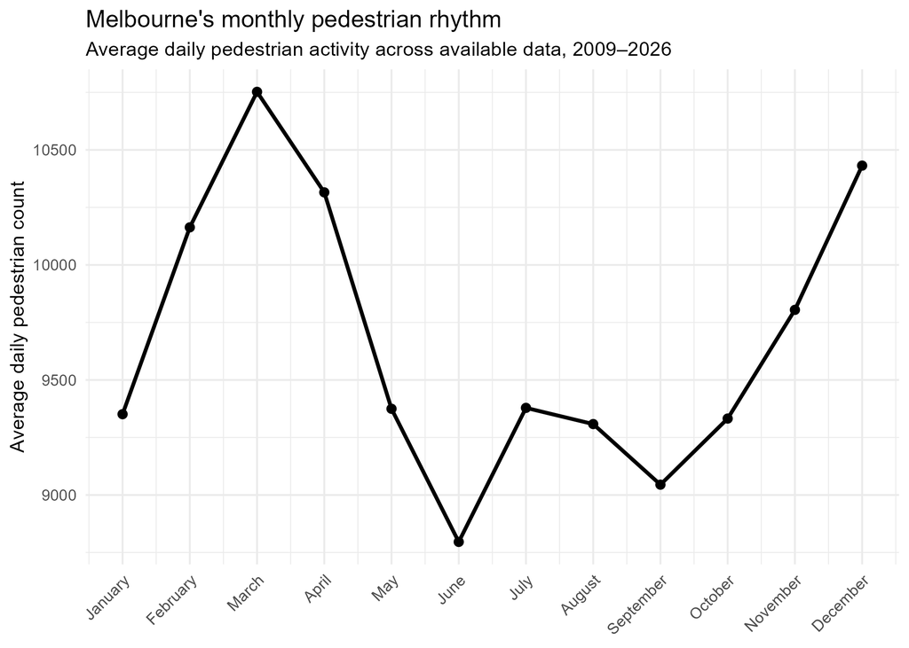

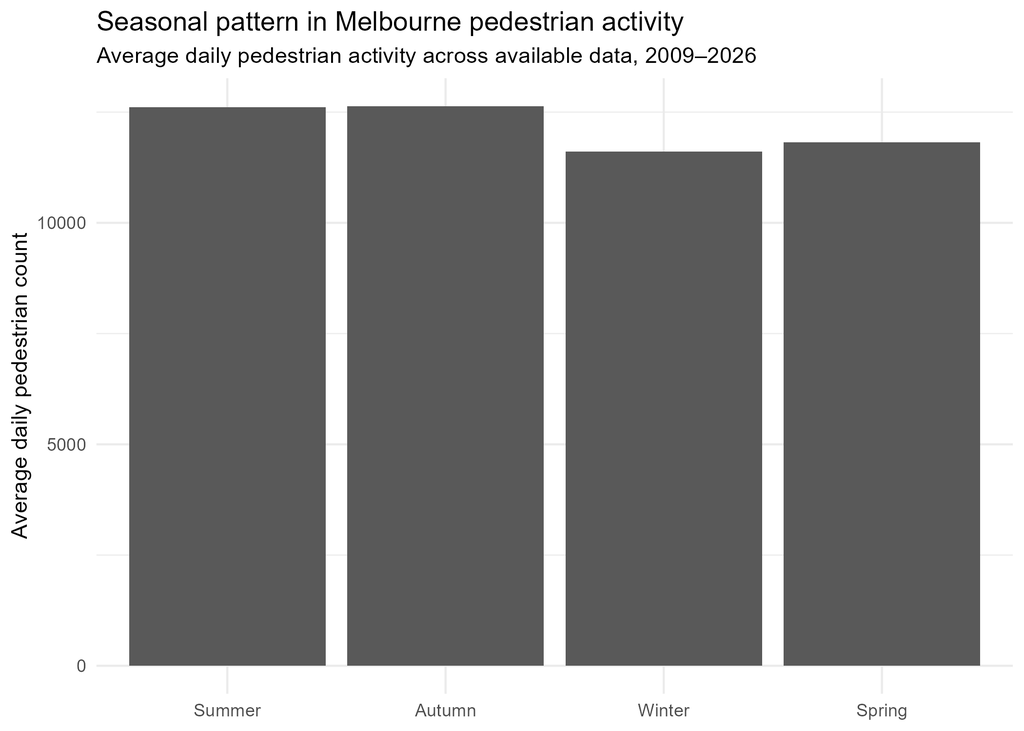

## Melbourne’s pedestrian activity over time

[interactive chart not shown]

**Key finding:** COVID-19 marked a major break in Melbourne’s pedestrian activity, with sharp declines during 2020–2021.

## Has Melbourne returned to its earlier pedestrian activity?

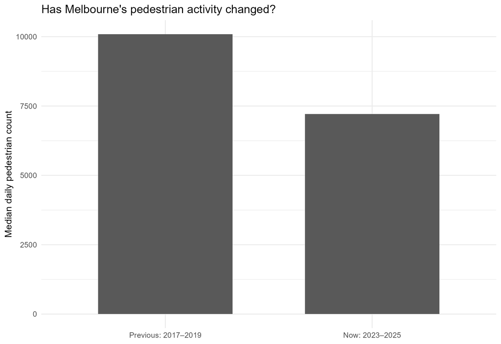

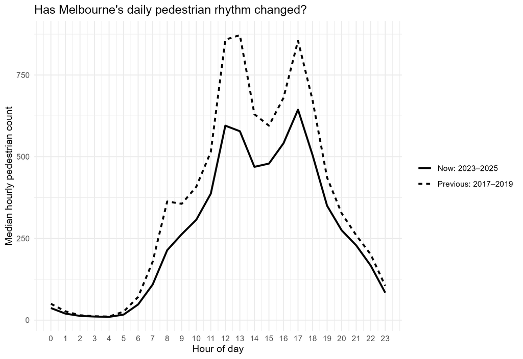

## Where is Melbourne busiest on foot?

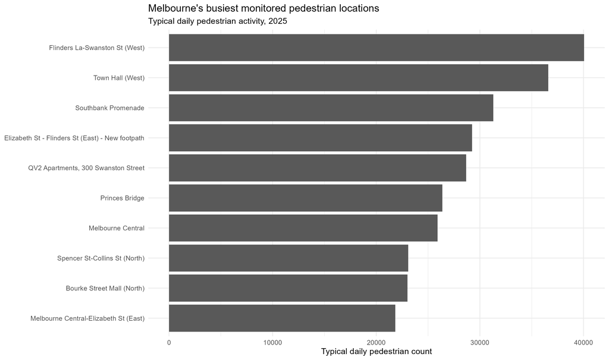

## Two distinct pedestrian rhythms

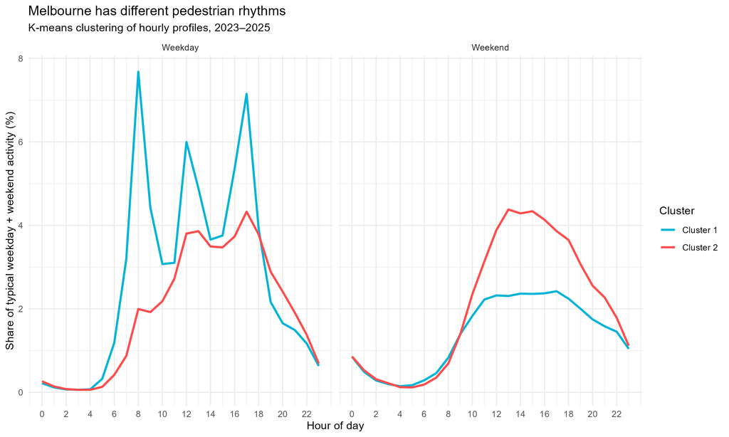

[interactive chart not shown]

**CLUSTER 1 · 9 SENSORS**

Stronger weekday-focused activity peaks.

**CLUSTER 2 · 35 SENSORS**

Broader daytime and weekend activity.

## Major pedestrian surges coincide with city events

[interactive chart not shown]

**22 February 2014:** The largest matched surge, with pedestrian activity **51.7% above expected levels**.

## When does Melbourne slow down?

[interactive chart not shown]

**HEAVY RAINFALL**

**24.7%** of days with ≥10 mm rainfall had significant pedestrian decreases, compared with **1.3%** of days with less rain.

**PUBLIC HOLIDAYS**

**34.9%** of public holidays had significant pedestrian decreases, compared with **2.5%** of other days.

## Melbourne has a rhythm - but it never stands still.

01

**One city, different rhythms**

Melbourne follows familiar daily and weekly patterns, but its streets don’t all move to the same beat.

02

**The city hasn’t returned to its old pace**

Across 27 consistently monitored locations, typical daily pedestrian activity was **28.5% lower in 2023–2025 than in 2017–2019**.

03

**Some days change everything**

Major events coincide with unexpected surges, while heavy rain and public holidays are linked to quieter streets.

**Melbourne’s rhythm isn’t just about when people move. It’s about where they go, how the city has changed, and what brings it to life.**